# CFSTRenD package user guide

An R Markdown Guide

2025-01-28

# Introduction

**CFSTRenD** R package aimed at streamlining the processing and analysis of tree-ring data. Key features include:

```
 1. manipulation and summarization of tree-ring data;
 2. data quality identification and classification;
 3. a flexible detrending and climate-growth model based on generalized additive mixed models (GAMM);
 4. model selection tool based on Akaike Information Criterion (AIC).
```

This vignette provides a precise guide to navigating key aspects of data processing, quality assessment, and modeling using the CFSTRenD package. Two datasets are used for demonstration:

- samples69.csv: A subset of the project Douglas-fir Retrospective Monitoring, freely available from the online CFS-TRenD data collection ([https://ts.nrcan.gc.ca/treerings]). This dataset contains species Douglas-fir(Pseudotsuga menziesii) data from 20 sites, totaling 257 samples with ring-width measurements in a wide format.
- clim69.csv: Annual winter frostdays (FFD) data corresponding to the same 20 sites included in samples69.csv.

We start by loading the datasets:

```r
library(data.table)
library(CFSTRenD)
# read ring measurement
 samples69.o <- fread(system.file("extdata", "samples69.csv", package = "CFSTRenD"))
 # read climate
clim69 <- fread(system.file("extdata", "clim69.csv", package = "CFSTRenD"))
```

# Functionality

## 1. data manipulation and reporting

### 1.1 Convert to CFS-TRenD format

This is to generates formatted tables aligning with CFS-TRenD structure, ensuring compatibility for data submission and integration.

```r
samples69.trt <- CFS_format(data = list(samples69.o, 39:140), usage = 1, out.csv = NULL)
```

```
#> [1] "you have filled all the mandatory information"
#> [1] "you have filled all the un-mandatory information"
```

#### 1.1.1 generating data report

```r
# for data submission
# generate_report(samples69.trt, usage = 1, output_file = NULL)
# for modelling
# generate_report(samples69.trt, usage = 2, output_file = NULL)
```

** note that if any variable is missing in users’ dataset, the system will prompt an alert to request users to fill it for mandatory information or fill it with NA for un-mandatory information under users’ permission.**

### 1.2 spatially frequency distribution

This function is to count the number of trees (uid_tree) with longitude-latitude per 1 degree.

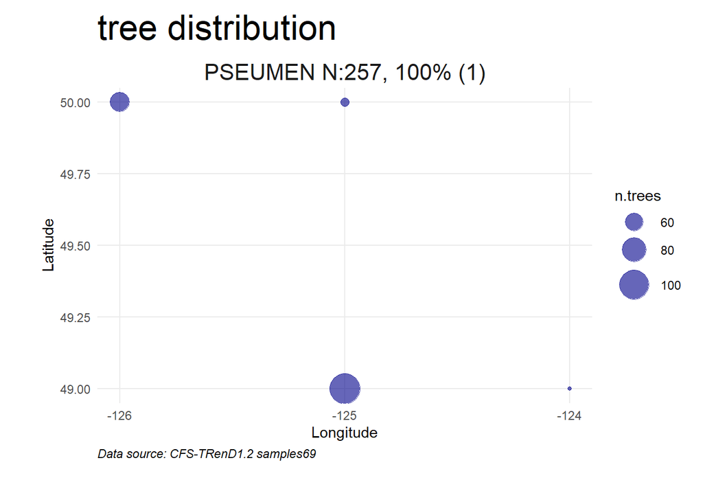

```r
samples69 <- samples69.trt$tr_all_wide
# print(samples69[, .N, by = .(latitude, longitude, uid_site)])
dt.freq <- CFS_freq(samples69, uid_level = "uid_tree",  geo_resolution = c(1,1))
plots_freq(dt.freq, out.species = "all", caption = "CFS-TRenD1.2 samples69", out.pdf= NULL )
```

## 2. data quality assessment

### 2.1 compare on ring width measurement

This function is to compare the median of ring width measruement of one specific site with those of the nearby sites using k-NN method.

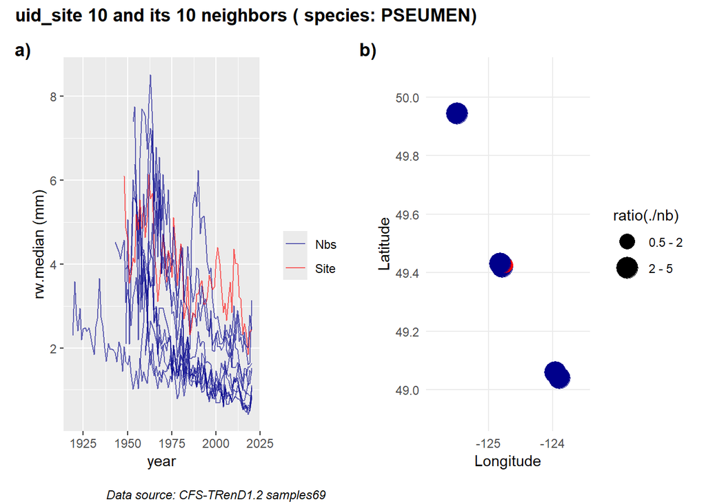

```r
# CFS_scale()
# specify the site and species to check
site.chk <- samples69[uid_site == 10 & species == "PSEUMEN",c("species", "uid_site", "site_id", "latitude", "longitude")][, .SD[1]]

dt.scale <- CFS_scale(site2chk = site.chk, ref_sites = samples69, N.nbs = 10, make.plot = list(TRUE, "CFS-TRenD1.2 samples69"))
```

### 2.2 quality assessment

This is to assess tree-ring measurement accuracy using a treated series based on the differences between two consecutive tree-ring measurements

```r
 samples69_long <- merge(samples69.trt$tr_all_wide[, c("uid_site", "site_id", "species", "uid_tree", "uid_sample", "uid_radius")],
   samples69.trt$tr_all_long$tr_7_ring_widths, by = "uid_radius")
# Calculate BAI
# rename to the reserved column name
setnames(samples69_long, c("uid_sample", "year", "rw_mm"), c("SampleID", "Year" ,"RawRing"))
# check duplication
samples69_long[, .N, by = .(SampleID, Year)][N>1]
```

```
#> Empty data.table (0 rows and 3 cols): SampleID,Year,N
```

```r
# include RW_trt, this is the series that qa process works on,
samples69_long[, RW_trt:= RawRing - shift(RawRing), by = SampleID]
# run quality assessment procedure
qa.trt.ccf <-CFS_qa(dt.input = samples69_long)
```

```
#> Progress pair-wise ccf...
#>
#> [1] "1 N.pass: 254"
#> [1] "2 N.pass: 231"
#> [1] "3 N.pass: 228"
```

```r
# print(qa.trt.ccf$dt.stats)
# qa_code frequency
qa.trt.ccf$dt.ccf[, .N, by = .(SampleID, qa_code)][, .N, by = .(qa_code)]
```

```
#>       qa_code     N
#>        <char> <int>
#> 1:       pass   228
#> 2:       Fail    17
#> 3: borderline    12
```

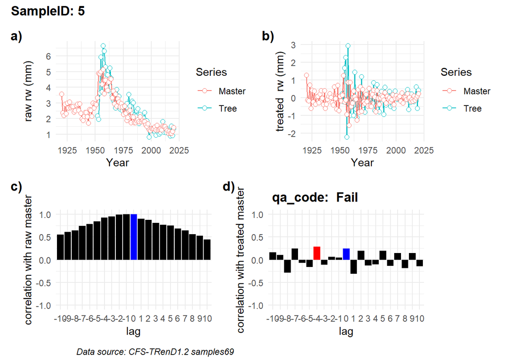

```r
# SampleID list
# unique(qa.trt.ccf$dt.ccf$SampleID)

# plot specific samples, figure output to screen
plots_qa(plot.lst = qa.trt.ccf$plot.lst, out.series = c("5"), caption = "CFS-TRenD1.2 samples69", out.pdf = NULL )
```

```r
# plot all series, figures output to a pdf file
# plots_qa(qa.trt.ccf$plot.lst, out.series = "all", out.pdf = "c:/tmp/qa.pdf" )
```

## 3. detrending and climate-growth model

### 3.1 series-level detrending model

```r
series.i <- samples69.trt$tr_all_long$tr_7_ring_widths[uid_radius == 1]
m.radius <- gamm_radius(data = series.i, m.candidates = "rw_mm ~ s(year)" )
summary(m.radius$model$gam)
```

```
#>
#> Family: gaussian
#> Link function: identity
#>
#> Formula:
#> log(rw_mm) ~ s(year)
#>
#> Parametric coefficients:
#>             Estimate Std. Error t value Pr(>|t|)
#> (Intercept)  1.23691    0.07609   16.25   <2e-16 ***
#> ---
#> Signif. codes:  0 '***' 0.001 '**' 0.01 '*' 0.05 '.' 0.1 ' ' 1
#>
#> Approximate significance of smooth terms:
#>           edf Ref.df     F  p-value
#> s(year) 2.441  2.441 16.72 9.52e-07 ***
#> ---
#> Signif. codes:  0 '***' 0.001 '**' 0.01 '*' 0.05 '.' 0.1 ' ' 1
#>
#> R-sq.(adj) =  0.821
#>   Scale est. = 0.050905  n = 60
```

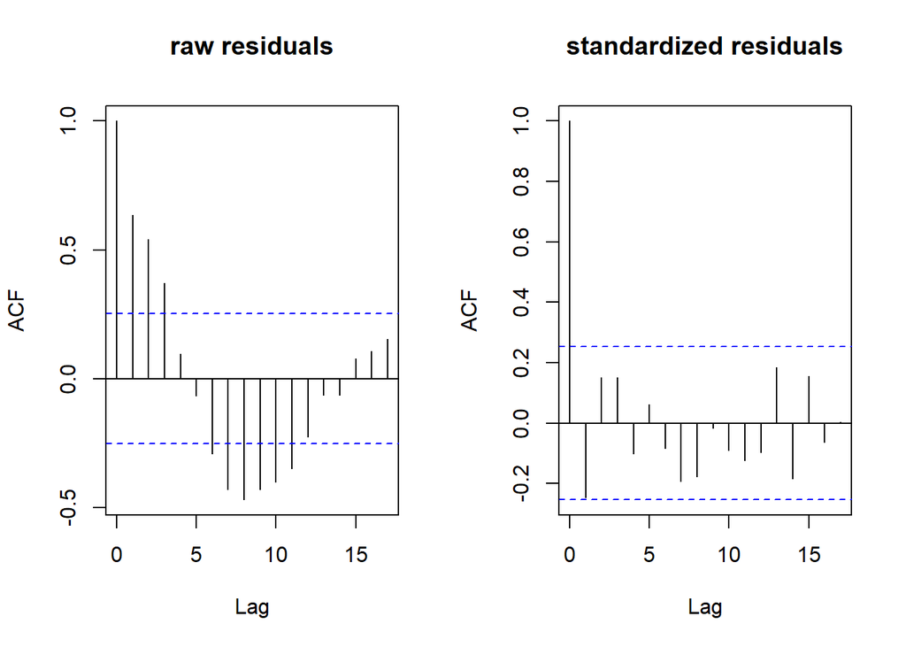

```r
par(mfrow = c(1, 2))

# Plot ACFs
acf(m.radius$pred$res.log_resp, plot = TRUE, main = "raw residuals")
acf(m.radius$pred$res.log_resp_normalized, plot = TRUE, main = "standardized residuals")
```

```r
# Reset layout
par(mfrow = c(1, 1))
```

### 3.2 site-level climate-growth model

The site-level function gamm_site() is used for the dataset within one-site with multiple series of tree ring measurement. It accounts for within-site variability and temporal autocorrelation by including tree identity as random effects and a first-order autoregressive (AR1) correlation structures.

#### prepare data for growth-climate model

```r
samples69_clim <- merge(samples69.trt$tr_all_wide[, c("uid_site", "site_id","latitude", "longitude",  "species", "uid_tree", "uid_radius")], samples69.trt$tr_all_long$tr_7_ring_widths, by = "uid_radius")

# # Calculate BAI
setorder(samples69_clim, uid_radius, year)
samples69_clim[, .N, by = .(uid_radius, year)][N>1]
```

```
#> Empty data.table (0 rows and 3 cols): uid_radius,year,N
```

```r
samples69_clim[, `:=`(ageC = seq_len(.N),
  radius = cumsum(rw_mm),  # Cumulative radius (assumes RW is added each year)
          radius_prev = shift(cumsum(rw_mm), fill = 0)), by = uid_radius]  # Previous radius (shifted)

# Compute previous BA in cm2
samples69_clim[, ba_cm2_t_1 := pi * (radius_prev^2)/100]

samples69_clim[, bai_cm2 := pi * (radius^2 - radius_prev^2)/100]


# Drop the radius columns if not needed
samples69_clim[, c("radius", "radius_prev") := NULL]

samples69_clim <- merge(samples69_clim, clim69, by = c("site_id", "year"))
```

#### site-level growth-climate model

```r
# samples69_clim[, uid_tree.fac:= as.factor(as.character(uid_tree))]
setorder(samples69_clim, uid_tree, year)
# choose 1 site, ignore the first 10 years as Girardin 2022
site.i <- samples69_clim[uid_site == 10][ageC > 10]
m.site <- gamm_site(data = site.i,
             m.candidates =   "bai_cm2 ~ log(ba_cm2_t_1) + s(ageC) + FFD"
             )

print(summary(m.site$model$gam))
```

```
#>
#> Family: gaussian
#> Link function: identity
#>
#> Formula:
#> log(bai_cm2) ~ log(ba_cm2_t_1) + s(ageC) + FFD
#>
#> Parametric coefficients:
#>                  Estimate Std. Error t value Pr(>|t|)
#> (Intercept)     -1.552146   0.859279  -1.806  0.07164 .
#> log(ba_cm2_t_1)  0.768778   0.138084   5.567 4.84e-08 ***
#> FFD             -0.003764   0.001199  -3.141  0.00181 **
#> ---
#> Signif. codes:  0 '***' 0.001 '**' 0.01 '*' 0.05 '.' 0.1 ' ' 1
#>
#> Approximate significance of smooth terms:
#>           edf Ref.df     F p-value
#> s(ageC) 3.444  3.444 4.638 0.00315 **
#> ---
#> Signif. codes:  0 '***' 0.001 '**' 0.01 '*' 0.05 '.' 0.1 ' ' 1
#>
#> R-sq.(adj) =  0.658
#>   Scale est. = 0.22879   n = 393
```

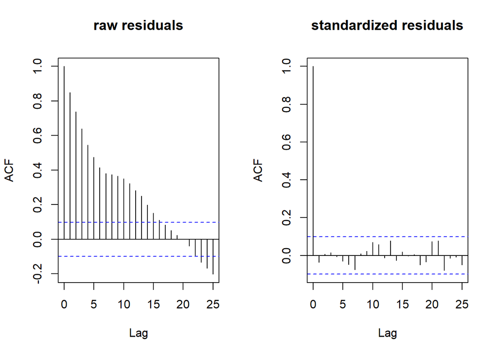

```r
# knitr::kable(m.site$fitting, caption = "Fitting REML Results")
par(mfrow = c(1, 2))

# Plot ACFs
acf(m.site$pred$res.log_resp, plot = TRUE, main = "raw residuals")
acf(m.site$pred$res.log_resp_normalized, plot = TRUE, main = "standardized residuals")
```

```r
# Reset layout
par(mfrow = c(1, 1))
```

### 3.3 spatial growth-climate model (multiple sites)

The gamm_spatial() function handles moderate geographic coverage by accounting for among-site and within-site variability with random effects for site and tree identities, respectively, and temporal autocorrelation using an AR1 structure. If spatial autocorrelation persists, the model refits automatically with a smooth term for latitude and longitude using the Spatial Over-Smooth (“sos”) basis.

```r
# samples69_clim[, uid_tree.fac:= as.factor(as.character(uid_tree))]
setorder(samples69_clim, uid_tree, year)
# choose 1 site, ignore the first 10 years as Girardin 2022
m.sp <- gamm_spatial(data = samples69_clim[ageC > 10],
             m.candidates = "bai_cm2 ~ log(ba_cm2_t_1) + s(ageC) + FFD"
             )
print(summary(m.sp$model$gam))
```

```
#>
#> Family: gaussian
#> Link function: identity
#>
#> Formula:
#> log(bai_cm2) ~ log(ba_cm2_t_1) + s(ageC) + FFD + s(uid_site.fac,
#>     bs = "re")
#>
#> Parametric coefficients:
#>                   Estimate Std. Error t value Pr(>|t|)
#> (Intercept)     -3.2511233  0.1664112  -19.54   <2e-16 ***
#> log(ba_cm2_t_1)  1.0035303  0.0272001   36.89   <2e-16 ***
#> FFD             -0.0045708  0.0002068  -22.10   <2e-16 ***
#> ---
#> Signif. codes:  0 '***' 0.001 '**' 0.01 '*' 0.05 '.' 0.1 ' ' 1
#>
#> Approximate significance of smooth terms:
#>                    edf Ref.df       F p-value
#> s(ageC)          7.729  7.729 198.920  <2e-16 ***
#> s(uid_site.fac) 16.705 19.000   8.739  <2e-16 ***
#> ---
#> Signif. codes:  0 '***' 0.001 '**' 0.01 '*' 0.05 '.' 0.1 ' ' 1
#>
#> R-sq.(adj) =   0.69
#>   Scale est. = 0.14514   n = 13272
```

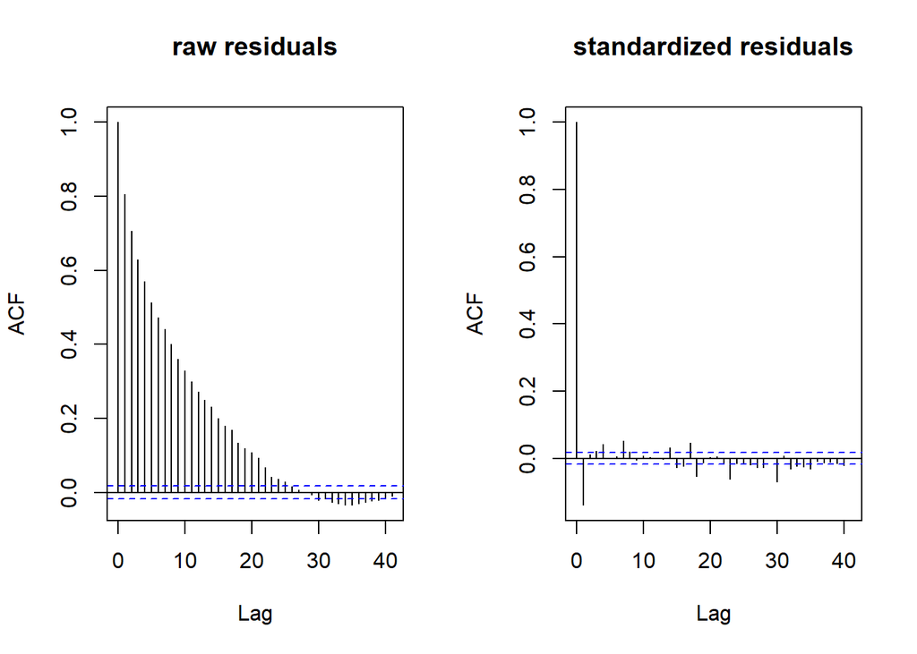

```r
par(mfrow = c(1, 2))

# Plot ACFs
acf(m.sp$pred$res.log_resp, plot = TRUE, main = "raw residuals")
acf(m.sp$pred$res.log_resp_normalized, plot = TRUE, main = "standardized residuals")
```

```r
# Reset layout
# par(mfrow = c(1, 1))
```

### 3.4 spatial growth-climate model (very large dataset and geographical coverage)

The bam_spatial() function addresses the computational challenges of analyzing large datasets with extensive geographic coverage, where GAMMs become a limitation. It combines the efficiency of the bam() function from the mgcv package with post-hoc residualization methods from the itsadug package to manage temporal autocorrelation. The function incorporates site and tree identities as random effects and includes an AR1 structure for temporal autocorrelation. When spatial autocorrelation persists, it refits the model with a thin-plate (“tp”) basis for latitude and longitude to account for spatial dependence.

```r
# samples69_clim[, uid_tree.fac:= as.factor(as.character(uid_tree))]
setorder(samples69_clim, uid_tree, year)
# choose 1 site, ignore the first 10 years as Girardin 2022
m.spp <- bam_spatial(data = samples69_clim[ageC > 10],
             m.candidates = "bai_cm2 ~ log(ba_cm2_t_1) + s(ageC) + FFD"
             )

print(summary(m.spp$model))
```

```
#>
#> Family: gaussian
#> Link function: identity
#>
#> Formula:
#> log(bai_cm2) ~ log(ba_cm2_t_1) + s(ageC) + FFD + s(uid_site.fac,
#>     bs = "re")
#>
#> Parametric coefficients:
#>                   Estimate Std. Error t value Pr(>|t|)
#> (Intercept)     -3.4095751  0.1371008  -24.87   <2e-16 ***
#> log(ba_cm2_t_1)  1.0327083  0.0215678   47.88   <2e-16 ***
#> FFD             -0.0045856  0.0002086  -21.99   <2e-16 ***
#> ---
#> Signif. codes:  0 '***' 0.001 '**' 0.01 '*' 0.05 '.' 0.1 ' ' 1
#>
#> Approximate significance of smooth terms:
#>                    edf Ref.df      F p-value
#> s(ageC)          7.672  8.422 253.07  <2e-16 ***
#> s(uid_site.fac) 18.198 19.000  25.53  <2e-16 ***
#> ---
#> Signif. codes:  0 '***' 0.001 '**' 0.01 '*' 0.05 '.' 0.1 ' ' 1
#>
#> R-sq.(adj) =  0.694   Deviance explained = 69.4%
#> fREML = 333.03  Scale est. = 0.16461   n = 13272
```

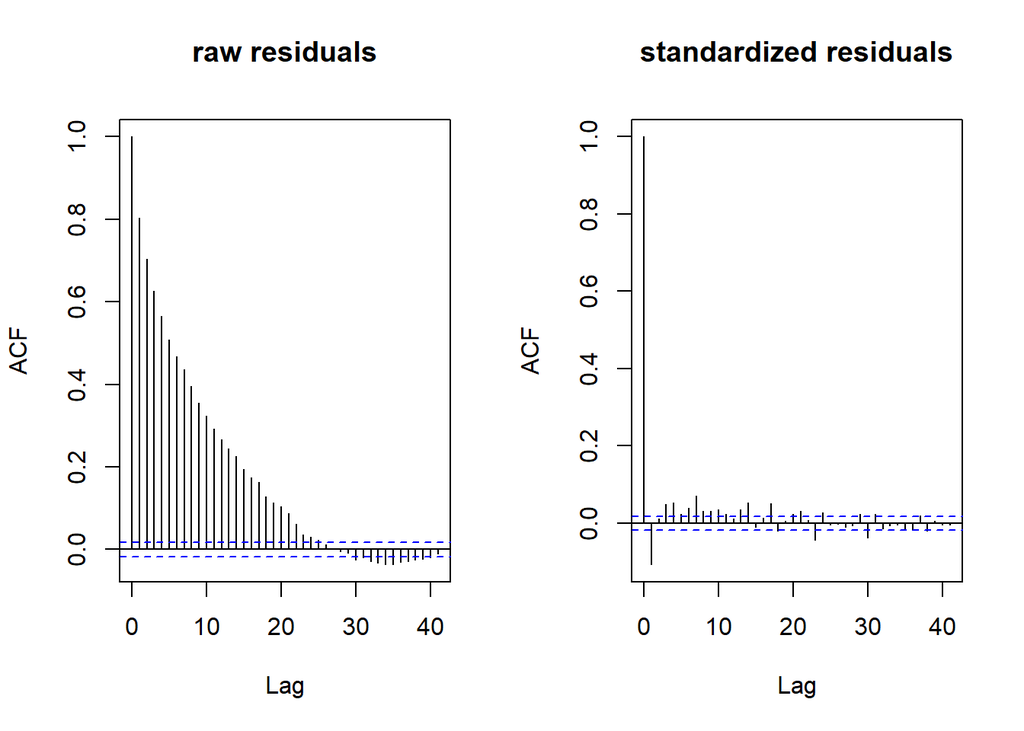

```r
par(mfrow = c(1, 2))

# Plot ACFs
acf(m.spp$pred$res.log_resp, plot = TRUE, main = "raw residuals")
acf(m.spp$pred[!is.na(res.log_resp_normalized)]$res.log_resp_normalized, plot = TRUE, main = "standardized residuals")
```

```r
# Reset layout
# par(mfrow = c(1, 1))
```

## 4 model selection

The modelling framework of section 3 can be served as model selection tool if users specify multiple candidate models through m.candiates argument. Each candidate model is initially fitted using the maximum likelihood (ML) method to ensure a fair comparison based on the Akaike Information Criterion (AIC). Then it is refitted using the restricted maximum likelihood (REML) method to obtain unbiased estimates of model parameters .

Below we take site-level model as an example. The result is exactly the same as those of section 3.2

```r
# samples69_clim[, uid_tree.fac:= as.factor(as.character(uid_tree))]
setorder(samples69_clim, uid_tree, year)
# choose 1 site, ignore the first 10 years as Girardin 2022
site.i <- samples69_clim[uid_site == 10][ageC > 10]
m.site <- gamm_site(data = site.i,
             m.candidates = c(
  "bai_cm2 ~ log(ba_cm2_t_1) + s(ageC)",
  "bai_cm2 ~ log(ba_cm2_t_1) + s(ageC) + FFD",
  "bai_cm2 ~ log(ba_cm2_t_1) + s(ageC) + s(FFD)"

)
)
# print(m.site$fitting_ML)
knitr::kable(m.site$fitting_ML, caption = "Fitting ML Results")
```

Fitting ML Results

| i | form | aic | R2 | methd | selected |
| --- | --- | --- | --- | --- | --- |
| 1 | log(bai_cm2) ~ log(ba_cm2_t_1) + s(ageC) | 2.528470 | 0.6673651 | ML | NA |
| 2 | log(bai_cm2) ~ log(ba_cm2_t_1) + s(ageC) + FFD | -5.212996 | 0.6633917 | ML | * |
| 3 | log(bai_cm2) ~ log(ba_cm2_t_1) + s(ageC) + s(FFD) | -4.430096 | 0.6642337 | ML | NA |

```r
print(summary(m.site$model$gam))
```

```
#>
#> Family: gaussian
#> Link function: identity
#>
#> Formula:
#> log(bai_cm2) ~ log(ba_cm2_t_1) + s(ageC) + FFD
#>
#> Parametric coefficients:
#>                  Estimate Std. Error t value Pr(>|t|)
#> (Intercept)     -1.552146   0.859279  -1.806  0.07164 .
#> log(ba_cm2_t_1)  0.768778   0.138084   5.567 4.84e-08 ***
#> FFD             -0.003764   0.001199  -3.141  0.00181 **
#> ---
#> Signif. codes:  0 '***' 0.001 '**' 0.01 '*' 0.05 '.' 0.1 ' ' 1
#>
#> Approximate significance of smooth terms:
#>           edf Ref.df     F p-value
#> s(ageC) 3.444  3.444 4.638 0.00315 **
#> ---
#> Signif. codes:  0 '***' 0.001 '**' 0.01 '*' 0.05 '.' 0.1 ' ' 1
#>
#> R-sq.(adj) =  0.658
#>   Scale est. = 0.22879   n = 393
```

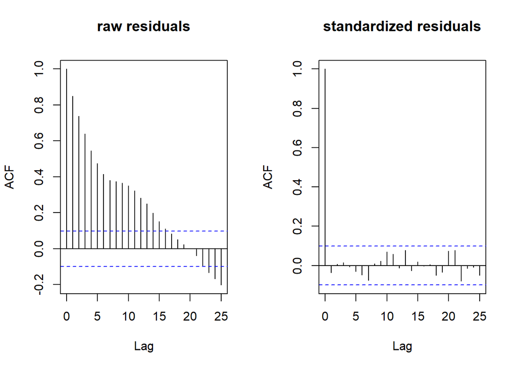

```r
par(mfrow = c(1, 2))

# Plot ACFs
acf(m.site$pred$res.log_resp, plot = TRUE, main = "raw residuals")
acf(m.site$pred$res.log_resp_normalized, plot = TRUE, main = "standardized residuals")
```

```r
# Reset layout
par(mfrow = c(1, 1))
```

## 5 reporting

```r
# generate_report(m.radius, output_file = NULL)
```